# Predicción de la calidad del levantamiento de mancuerna con datos de acelerómetros

Luis Raigoso

10/10/2026

## Resumen

El objetivo es predecir la variable `classe` (A–E), que indica cómo 6 participantes realizaron levantamientos de mancuerna: A es la forma correcta y B–E corresponden a cuatro errores típicos. Se usan los datos de acelerómetros del cinturón, antebrazo, brazo y mancuerna. Se entrena un Random Forest, se valida con validación cruzada de 5 particiones y con un conjunto de validación apartado, y se predicen los 20 casos de prueba.

Fuente de datos: Velloso, E.; Bulling, A.; Gellersen, H.; Ugulino, W.; Fuks, H. *Qualitative Activity Recognition of Weight Lifting Exercises*. Proceedings of 4th International Conference in Cooperation with SIGCHI (Augmented Human ’13). Stuttgart, 2013. http://web.archive.org/web/20161224072740/http:/groupware.les.inf.puc-rio.br/har

## Carga y limpieza

```r
train_raw <- read.csv("base/pml-training.csv", na.strings = c("NA", "", "#DIV/0!"))
test_raw  <- read.csv("base/pml-testing.csv",  na.strings = c("NA", "", "#DIV/0!"))
dim(train_raw); dim(test_raw)
```

```
## [1] 19622   160
```

```
## [1]  20 160
```

Decisiones de limpieza:

1. Se eliminan las columnas de identificación y tiempo (`X`, usuario, marcas de tiempo, ventanas). Dejarlas permitiría “hacer trampa”: `X` está ordenada por `classe`.
2. Se eliminan las columnas con más del 90 % de valores faltantes (son estadísticos resumen de cada ventana, y en los 20 casos de prueba están vacíos, por lo que no sirven para predecir).
3. Se conservan solo las variables presentes y numéricas en el conjunto de prueba.

```r
id_cols <- 1:7
tr <- train_raw[, -id_cols]
te <- test_raw[,  -id_cols]

pct_na <- colMeans(is.na(tr))
keep <- names(pct_na)[pct_na < 0.9]
keep <- setdiff(keep, "classe")
keep <- keep[sapply(tr[keep], is.numeric)]
keep <- keep[keep %in% names(te) & colSums(is.na(te[keep])) == 0]

tr <- data.frame(tr[keep], classe = factor(train_raw$classe))
te <- te[keep]
length(keep)
```

```
## [1] 52
```

Quedan 52 predictores sin valores faltantes.

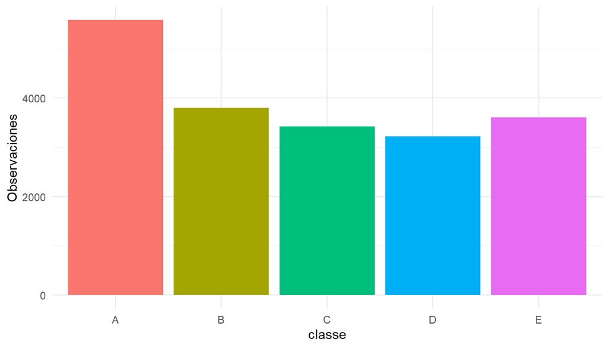

Distribución de la variable classe en el entrenamiento.

```r
ggplot(tr, aes(classe, fill = classe)) + geom_bar(show.legend = FALSE) +
  labs(x = "classe", y = "Observaciones") + theme_minimal()
```

Las clases están razonablemente balanceadas (A es la más frecuente), por lo que la exactitud es una métrica adecuada.

## Estrategia de modelado y validación

- **Partición**: 70 % entrenamiento / 30 % validación (estratificada por `classe`). El 30 % no se toca hasta el final y da una estimación independiente del error fuera de muestra.
- **Validación cruzada**: 5 particiones sobre el 70 % de entrenamiento, para comparar el número de variables por árbol (`mtry`) y estimar el error.
- **Modelo**: Random Forest. Maneja bien relaciones no lineales e interacciones entre sensores, no requiere escalar variables y es robusto a predictores correlacionados.

```r
idx <- unlist(lapply(split(seq_len(nrow(tr)), tr$classe),
                     function(i) sample(i, round(0.7 * length(i)))))
train <- tr[idx, ]
valid <- tr[-idx, ]
c(train = nrow(train), valid = nrow(valid))
```

```
## train valid
## 13735  5887
```

```r
k <- 5
folds <- sample(rep(1:k, length.out = nrow(train)))
mtrys <- c(4, 8, 16, 27)

cv_res <- do.call(rbind, lapply(mtrys, function(m) {
  acc <- sapply(1:k, function(f) {
    fit <- randomForest(classe ~ ., data = train[folds != f, ], mtry = m, ntree = 150)
    mean(predict(fit, train[folds == f, ]) == train$classe[folds == f])
  })
  data.frame(mtry = m, acc_media = mean(acc), sd = sd(acc))
}))
cv_res
```

```
##   mtry acc_media          sd
## 1    4 0.9920641 0.001809213
## 2    8 0.9924281 0.002065710
## 3   16 0.9918456 0.002607354
## 4   27 0.9899527 0.001660248
```

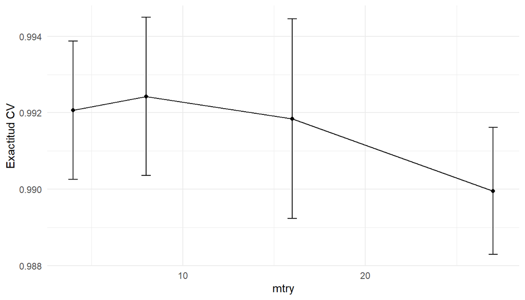

Exactitud de validación cruzada (5 particiones) según mtry.

```r
ggplot(cv_res, aes(mtry, acc_media)) +
  geom_line() + geom_point() +
  geom_errorbar(aes(ymin = acc_media - sd, ymax = acc_media + sd), width = 0.5) +
  labs(x = "mtry", y = "Exactitud CV") + theme_minimal()
```

```r
best_m <- cv_res$mtry[which.max(cv_res$acc_media)]
modelo <- randomForest(classe ~ ., data = train, mtry = best_m, ntree = 300, importance = TRUE)
modelo
```

```
##
## Call:
##  randomForest(formula = classe ~ ., data = train, mtry = best_m,      ntree = 300, importance = TRUE)
##                Type of random forest: classification
##                      Number of trees: 300
## No. of variables tried at each split: 8
##
##         OOB estimate of  error rate: 0.52%
## Confusion matrix:
##      A    B    C    D    E  class.error
## A 3903    2    0    0    1 0.0007680492
## B   13 2640    5    0    0 0.0067720090
## C    1   14 2373    7    0 0.0091858038
## D    0    0   19 2230    2 0.0093291870
## E    0    0    2    5 2518 0.0027722772
```

Se elige `mtry =` 8 por mayor exactitud en validación cruzada.

## Error fuera de muestra

```r
pred_valid <- predict(modelo, valid)
cm <- table(Predicho = pred_valid, Real = valid$classe)
cm
```

```
##         Real
## Predicho    A    B    C    D    E
##        A 1674   11    0    0    0
##        B    0 1126    7    0    0
##        C    0    2 1018    7    0
##        D    0    0    2  956    1
##        E    0    0    0    2 1081
```

```r
acc_valid <- mean(pred_valid == valid$classe)
acc_valid
```

```
## [1] 0.9945643
```

La exactitud en el conjunto de validación es **99.46 %**, por lo que el **error esperado fuera de muestra es de aproximadamente 0.54 %**. Es coherente con el error OOB del bosque y con la validación cruzada (0.76 %). Aviso: la validación aleatoria mezcla ventanas del mismo participante entre entrenamiento y validación, así que el error en participantes nuevos podría ser algo mayor.

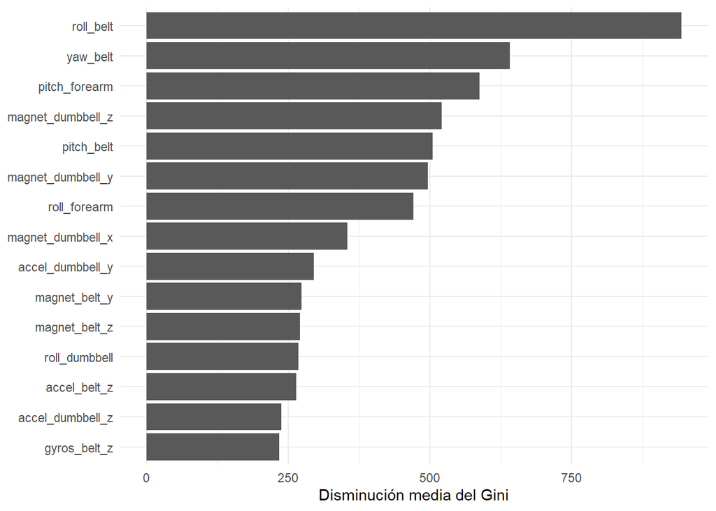

Las 15 variables más importantes (disminución media del índice Gini).

```r
imp <- data.frame(variable = rownames(modelo$importance),
                  gini = modelo$importance[, "MeanDecreaseGini"])
imp <- head(imp[order(-imp$gini), ], 15)
ggplot(imp, aes(reorder(variable, gini), gini)) + geom_col() + coord_flip() +
  labs(x = NULL, y = "Disminución media del Gini") + theme_minimal()
```

## Predicción de los 20 casos de prueba

Se reentrena con todos los datos de entrenamiento (`mtry` elegido) y se predice.

```r
modelo_final <- randomForest(classe ~ ., data = tr, mtry = best_m, ntree = 300)
pred_test <- predict(modelo_final, te)
data.frame(caso = seq_along(pred_test), prediccion = pred_test)
```

```
##    caso prediccion
## 1     1          B
## 2     2          A
## 3     3          B
## 4     4          A
## 5     5          A
## 6     6          E
## 7     7          D
## 8     8          B
## 9     9          A
## 10   10          A
## 11   11          B
## 12   12          C
## 13   13          B
## 14   14          A
## 15   15          E
## 16   16          E
## 17   17          A
## 18   18          B
## 19   19          B
## 20   20          B
```

Respuestas para el cuestionario: B A B A A E D B A A B C B A E E A B B B